# Régression Logistique

Séance 3

Florent Chuffart & Magali Richard (d’après le cours de Lydiane Agier)

20 Novembre 2018

# Plan

1. Rappel : Modèle, OR, RR et test de significativité
2. Adequation du modèle aux données
3. Réduction de variables

## I) Rappel régression logistique : notation et modèle

### Principe

Objectif : Modéliser une **variable binaire** en fonction d’une ou plusieurs autres covariables (quali ou quanti)
$$Y \sim X$$
$$E(Y|X) \sim X$$

Par exemple, on cherche à connaitre la probabilité qu’un individu soit un homme sachant sa taille, son poids, ses habitudes alimentaires.

### La fonction *logit*

$$\begin{eqnarray}
\text{logit: } ]0,1[ & \rightarrow & \mathbb{R} \\
x & \rightarrow & logit(x) = log(\frac{x}{1-x}) \\
logit^{-1}(y) = \frac{1}{1+e^{-y}} & \rightarrow & y
\end{eqnarray}$$

### La régression logistique

Comme en régression linéaire, l’objet de cette modélisation est *d’estimer les coefficients $\beta$* :

$$\begin{eqnarray}
logit(E(Y|X)) & = & \beta X \\
logit(P(Y=1|X)) & = & \beta X \\
logit(\pi(X)) & = & \beta X \\
\pi(X) & = & logit^{-1}(\beta X)
\end{eqnarray}$$

On obtient ainsi $\pi(X)$, le prédicteur de Y en fonction de X.

## I) Rappel régression logistique : vraisemblance

- **Définition** : Probabilité d’observer un évènement si le modèle envisagé est vrai
- Le modèle conditionnel de $Y$ sachant $X$ est : $E(Y|X = x) \sim B(\pi(x))$
- Pour l’observation $i$, la contribution à la vraisemblance est donc:
  $$l(x_i, y_i) = P(y_i = 1|x_i)^{y_i} (1-P(y_i=1|x_i))^{1-y_i} = \pi(x_i)^{y_i}(1-\pi(x_i))^{1-y_i}$$

si $y_i = 1$ :
$$\begin{eqnarray}
l(x_i, 1) &=& P(y_i = 1|x_i)^1 (1-P(y_i=1|x_i))^0 &=& \pi(x_i)^1 (1-\pi(x_i))^0 \\
&=& P(y_i = 1|x_i) 1 &=& \pi(x_i) 1 \\
&=& P(y_i = 1|x_i) &=& \pi(x_i) \\
\end{eqnarray}$$

si $y_i = 0$ :
$$\begin{eqnarray}
l(x_i, 0) &=& P(y_i = 1|x_i)^0 (1-P(y_i=1|x_i))^1 &=& \pi(x_i)^0(1-\pi(x_i))^1 \\
&=& 1 (1-P(y_i=1|x_i)) &=& 1 (1-\pi(x_i)) \\
&=& 1-P(y_i=1|x_i) &=& 1-\pi(x_i) \\
\end{eqnarray}$$

```r
d = read.table("data/data_nutri.csv", header=TRUE, sep=",", row.names = 1)
d$sex = as.factor(d$sex)
s = as.numeric(d$sex) - 1
#DT::datatable(d, width = "100%")
# head(d)
```

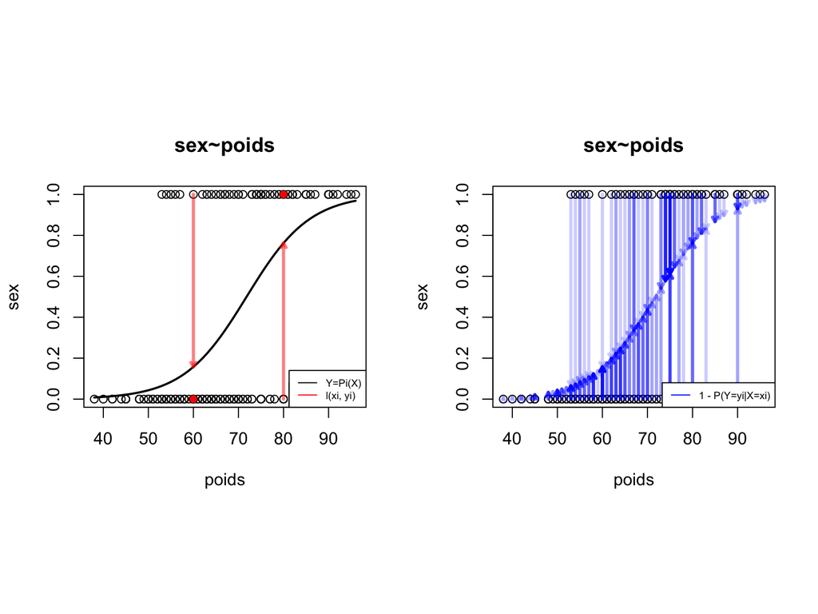

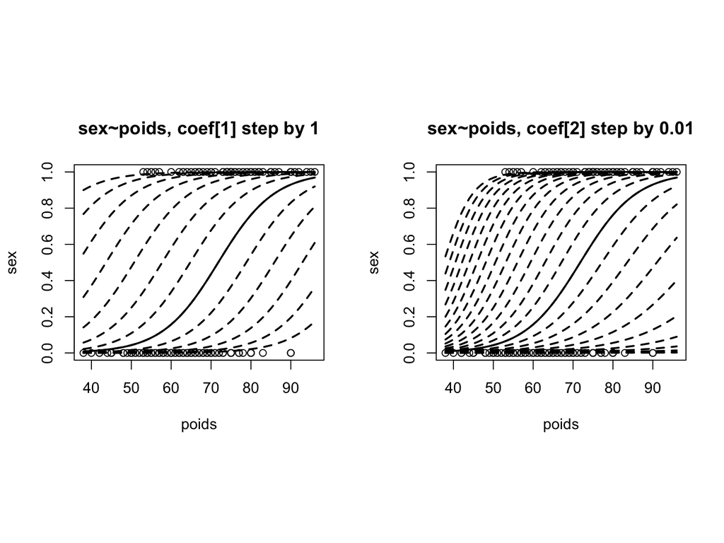

## I) Rappel regression logistique :

### Les mesures d’interêt

Comment interpréter $\widehat{\beta_k}$ ? Quel est l‘effet de la variable $X_k$ sur $logit(P(Y=1|X))$ ?

- *Définition* **odds**

$$Odds(X) = \frac{\pi(X)}{1-\pi(X)} \iff Odds(X) = e^{\beta X}$$

- *Définition* **odds ratio**

$$OR_{u/\nu} = \frac{odd(X = u)}{odd(X=\nu)} = e^{\beta (u-v)}$$

- *Définition* **risque relatif**

$$RR_{u/\nu} = \frac{\pi(X = u)}{\pi(X=\nu)} = \frac{P(Y=1|X=u)}{P(Y=1|X=\nu)}$$

**$OR$ est directement calculable à partir des coefficients de la régression $\beta$**

$OR$ estime le rapport malades/non-malades et $RR$ estime le risque (i.e. la probabilité) d’être malade.

Ils donnent la même indication sur la relation entre $Y$ et $X$ :

1. Si $RR_{u/\nu}$ (ou $OR_{u/\nu}$) $>1$ alors il y a plus de risque de $Y=1$ si $X=u$ que si $X=\nu$
2. Si $RR_{u/\nu}$ (ou $OR_{u/\nu}$) $<1$ alors il y a moins de risque de $Y=1$ si $X=u$ que si $X=\nu$
3. Si $RR_{u/\nu}$ (ou $OR_{u/\nu}$) $=1$ alors $Y$ n’est pas influencée par $X=u$ vs. $X=\nu$ (i.e. Y indépendant des catégories $u$ et $\nu$ de $X$)

## I) Rappel regression logistique :

### La significativité du paramêtre $\beta_k$

On veut tester l’influence du facteur $X_k$.

$$\left\lbrace
\begin{array}{l}
H_0 : {\beta_k = 0} \\
H_1 : {\beta_k \neq 0}
\end{array}
\right.$$

Test de Wald pour un unique paramètre : $T = \Big(\frac {\widehat\beta_k} {\widehat\sigma_{\widehat\beta_k}}\Big)^2 \sim \mathcal{X}^2_1$

### Comparaison de modèles emboités

On veut tester si l’ajout de paramètres est pertinent.

- Soit $m_1$ un modèle emboité dans $m_2$ (*i.e.* toutes les variables de $m_1$ sont dans $m_2$)
- $m_2$ comprend $p$ variables explicatives supplémentaires par rapport à $m_1$
- $L_1$ est la valeur de vraisemblance de $m_1$
- $L_2$ est la valeur de vraisemblance de $m_2$

Test du rapport de vraisemblance : $T = -2(log(L_1) - log(L_2)) \sim \mathcal{X}^2_p$

## II) Adéquation du modèle

Comment mesurer si le modèle construit **prédit de façon efficace** les données observées ?

Mesurer l’**adéquation** du modèle **aux données** c’est étudier essentiellement :

- L’*écart global* entre les valeurs prédites et les valeurs observées (i.e. mesures globales)

– Calibration du modèle (concordance entre les valeurs prédites et observées) : **Test de Hosmer-Lemeshow**

– Pouvoir discriminant du modèle : courbe **ROC** et critère **AUC** (Area Under Curve)

- La *contribution* de chaque observation au modèle (détection des outliers)

– Résidus de Pearson

– Résidus de déviance

## II) Adéquation du modèle : Test de Howmer-Lemeshow

### Principe

- Pour chaque observation $i$, on calcule la probabilité prédite $\widehat{P}(Y=1|x_i) = \widehat{\pi}(x_i)$.
- On regroupe les observations par quantiles de distribution de la valeur prédite (*i.e.* par valeurs croissantes en $K$ groupes $G_k$ de taille égale; on prend souvent $K=10$).
- Pour chaque groupe d’observations $G_k$ , on compare le nombre de sujets pour lesquels $Y=1$ ($n_{1k}$), au nombre de sujets malades prédits par le modèle ($\widehat{n}_{1k}$)

$$n_{1k} = \sum_{i\in{G_k}}y_i \ \ \ \ \ \ \ \ \ vs. \ \ \ \ \ \ \ \ \ \ \widehat{n}_{1k} = \sum_{i\in{G_k}}\widehat{\pi}(x_i)$$

- De même on calcule $n_{0k}$ et $\widehat{n}_{0k}$

$$n_{0k} = \sum_{i\in{G_k}} (1-y_i) \ \ \ \ \ \ \ \ \ vs. \ \ \ \ \ \ \ \ \ \ \widehat{n}_{1k} = \sum_{i\in{G_k}}(1-\widehat{\pi}(x_i))$$

- On compare ces valeurs observées $n_jk$ aux valeurs prédites $\widehat{n}_jk$ (on voudrait idéalement qu’elles soient égales) par un test de $\mathcal{X}^2_{K-2}$ à $K-2$ degrés de libertés

Rq: il faut que pour tout $k$, $n_jk >5$ et $\widehat{n}_jk >5$ pour pouvoir appliquer ce test.

## II) Adéquation du modèle : Test de Howmer-Lemeshow

### Exemple

$$H_0 : {\widehat{n}_{1k} = n_{1k}}, \forall j,k$$
$$H_1 : \exists (j,k), \widehat{n}_{1k} \neq n_{1k}$$

```r
m = glm(s~d$poids+d$taille+d$age, family = binomial(logit))
test = ResourceSelection::hoslem.test (s, m$fitted.values)
test
```

```
##
##  Hosmer and Lemeshow goodness of fit (GOF) test
##
## data:  s, m$fitted.values
## X-squared = 2.0559, df = 8, p-value = 0.9793
```

La p-valeur du test de Hosmer-Lemeslow est > 0.05, on consreve $H_0$ et les valeurs prédites et observées concordent bien, le modèle est bon.

Définition des groupes par quantiles de probabilités prédites $\widehat{\pi}(x_i)$

```r
test[[6]]
```

```
##
## cutyhat              y0 y1
##   [3.61e-05,0.00275] 23  0
##   (0.00275,0.00999]  23  0
##   (0.00999,0.0285]   22  0
##   (0.0285,0.0708]    21  2
##   (0.0708,0.189]     19  3
##   (0.189,0.467]      16  7
##   (0.467,0.679]      11 11
##   (0.679,0.906]       5 18
##   (0.906,0.974]       1 21
##   (0.974,1]           0 23
```

*Cutyhat*: Définition des groupes par quantiles de probabilités prédites $\widehat{\pi}(x_i)$

*y0 et y1*: $n_{jk}$ le nombre **observé** de sujets $Y=0$ et $Y=1$ par groupe

```r
test[[7]]
```

```
##
## cutyhat                    yhat0       yhat1
##   [3.61e-05,0.00275] 22.96825911  0.03174089
##   (0.00275,0.00999]  22.86225452  0.13774548
##   (0.00999,0.0285]   21.62155531  0.37844469
##   (0.0285,0.0708]    21.89756585  1.10243415
##   (0.0708,0.189]     19.40176024  2.59823976
##   (0.189,0.467]      16.74846922  6.25153078
##   (0.467,0.679]       9.92057543 12.07942457
##   (0.679,0.906]       4.29127453 18.70872547
##   (0.906,0.974]       1.12183574 20.87816426
##   (0.974,1]           0.16645000 22.83355000
```

*yhat0 et yhat1*: $n_{jk}$ le nombre **estimé** de sujets $Y=0$ et $Y=1$ par groupe

## II) Adéquation du modèle : courbe ROC

### Principe

Le **pouvoir discriminant** correspond à la capacité du modèle à correctement classer les observations.

- Pour chaque observation $i$, on calcule la probabilité prédite $\widehat{P}(Y=1|x_i) = \widehat{\pi}(x_i)$.
- On définit pour un seuil $s \in [0,1]$ choisi :
  $$\widehat{Y}_i = \Bigg\{
  \begin{align}
  1 && \text{si} && \widehat{\pi}(x_i) \geq s \\
  0 && \text{sinon}
  \end{align}$$
- La **proportion de bien classés** correspond à :
  $$\frac{\# \{\widehat{Y}_i = 1, Y_i = 1\} + \# \{\widehat{Y}_i = 0, Y_i = 0\}}{n}$$
- La **Sensibilité** correspond à la proportion de bien classées parmi les observations pour lesquelles $Y=1$,
  $$sensibilité = \frac{\# \{\widehat{Y}_i = 1, Y_i = 1\}}{\# \{Y_i = 1\}}$$
- La **Spécificité** correspond à la proportion de bien classées parmi les oservations pour lesquelles $Y=0$,
  $$spécificité = \frac{\# \{\widehat{Y}_i = 0, Y_i = 0\}}{\# \{Y_i = 0\}}$$
- On cherche à **maximiser sensibilité et spécificité** en faisant varier $s \in [0,1]$

## II) Adéquation du modèle : courbe ROC

### Exemple

On recherche le seuil $s$ optimum (souvent le plus proche de $sensibilité=1$ et $spécificité=1$)

```r
m = glm(s~d$poids+d$taille+d$age, family = binomial(logit))
ROC = pROC::roc(response=s, m$fitted.values)
```

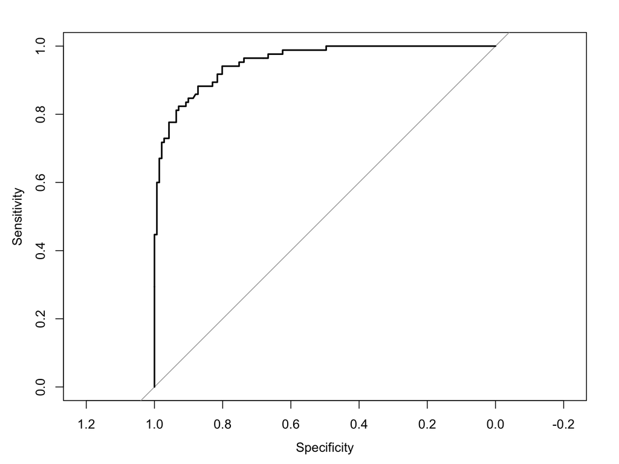

```r
plot(ROC, xlim=c(1,0))
```

On recherche le seuil pour lequel on maximise la sensibilité et la spécificité).

```r
plot(ROC, xlim=c(1,0))
test = (1-ROC$sensitivities)^2+(1-ROC$specificities)^2
wh = which(test==min(test))
ROC$thresholds[wh]
```

```
## [1] 0.3593199
```

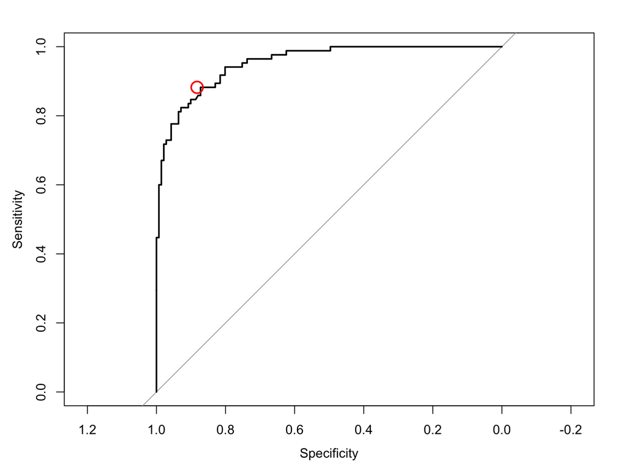

```r
points(ROC$sensitivities[wh], ROC$sensitivities[wh], col = 2, cex = 2, lwd = 2)
```

## II) Adéquation du modèle : AUC

### Principe

AUC signifie “aire sous la courbe ROC”.

| AUC | Discrimination |
| --- | --- |
| 0.5 | Nulle |
| 0.7 - 0.8 | Acceptable |
| 0.8 - 0.9 | Excellente |
| > 0.9 | Exceptionnelle |

Plus l’aire sous la courbe augmente, plus le modèle est capable de bien classer les observations:

- Si $AUC = 0.5$ alors le modèle classe de manière complètement aléatoire les observations
- Si $AUC > 0.9$ le modèle est très bon, voire trop bon, il faut évaluer s’il y a overfitting

## II) Adéquation du modèle : AUC

## Exemple

```r
m1 = glm(s~d$poids, family = binomial(logit))
m2 = glm(s~d$taille, family = binomial(logit))
m3 = glm(s~d$taille+d$poids, family = binomial(logit))
ROC1 = pROC::roc(response=s, m1$fitted.values)
ROC2 = pROC::roc(response=s, m2$fitted.values)
ROC3 = pROC::roc(response=s, m3$fitted.values)
```

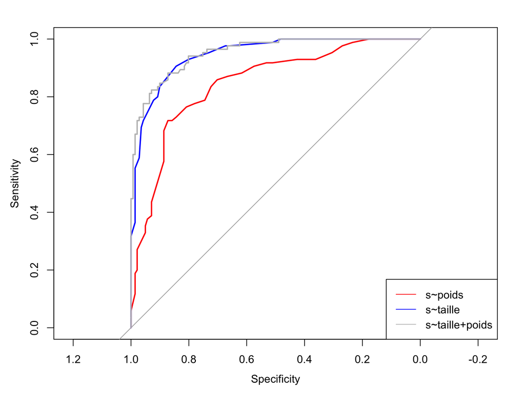

```r
plot(ROC1, xlim=c(1,0), col=2)
lines(ROC2, xlim=c(1,0), col=4)
lines(ROC3, xlim=c(1,0), col="grey")
legend("bottomright", lty=1, c("s~poids", "s~taille", "s~taille+poids"), col=c("2", "4", "grey"))
```

## II) Adéquation du modèle : les résidus

Résidus de Pearson :

$$r_{p_i} = \frac{Y_i - \widehat{\pi}_i}{\sqrt{\widehat{\pi}_i(1-\widehat{\pi}_i)}}$$

Résidus de déviance :

$$r_{D_i} = \left \lbrace
\begin{array}{l}
\sqrt(2|log(\widehat{\pi}_i)|) \ \ \ \ \text{si}\ Y_i=1 \\
- \sqrt(2|log(1-\widehat{\pi}_i)|) \ \ \ \ \text{si}\ Y_i=0
\end{array}
\right.$$

Rend compte de la contribution de chaque individu

Permet de détecter les valeus extrêmes

## III) Sélection de variables

- Critères de choix

  – Critère du $R^2$

  – Critètre d’information d’Akaike (AIC)

  – Critètre d’information bayesien (BIC)
- Procédure de sélection de variable

– Forward (ou pas à pas ascendante)

– Backward (ou pas à pas descendante)

– Stepwise

## III) Sélection de variables : c ritères

### Pseudo-$R^2$ (Cox-Snell, Nagelkerke)

Augmente de façon monotone avec l’introduction de nouvelles variables

### Critètre d’information d’Akaike (AIC)

Le critère AIC est défini par :

$$AIC = -2log(L_n(\widehat{\beta})) + 2p$$

### Critètre d’information bayesien (BIC)

Le critère BIC est défini par :

$$BIC = -2log(L_n(\widehat{\beta})) + p \log(n)$$

Pour l’AIC et le BIC :

- le critère s’applique aux modèles estimés par une méthode du **maximum de vraisemblance**
- le meilleur modèle est celui qui minimise le critère

Le BIC est plus parcimonieux que l’AIC puisqu’il pénalise plus le nombre de variables présentent de le modèle.

## III) Sélection de variables : méthodes

Méthodes les plus classiques:

- Forward (ou pas à pas ascendante)
- Backward (ou pas à pas descendante)
- Stepwise

Ces méthodes s’appuient sur les **données recueillies**

Elles sont **itératives**

Elle dépendent de **paramètres** (à valeur prédéfinie)

Bien que l’efficacité de ces méthodes ne puisse être démentie par la pratique, il ne serait pas raisonnable de se fier uniquement aux résultats statistiques fournis par un algorithme. En effet, pour décider d’ajouter ou de supprimer une variable dans un modèle, il faut conserver :

- une part d’intuition
- une part de déduction
- une part de synthèse

## III) Sélection de variables : forward

### Principe

1. On part du modèle le plus **simple** :
- Modèle vide (avec uniquement la constante)
- Ou modèle avec les variables d’ajustement
2. On **ajoute une à une** les variables :
- En se basant sur le test de rapport de vraisemblance
- En ajoutant à chaque pas, parmi les variables restantes, celle qui est la plus significative (selon un critère donné)
3. On **s’arrête quand il n’y a plus de variables à ajouter** (selon un critère prédéfini, eg. valeur minimale de p-valeur du test, en général 0.10)

## III) Sélection de variables : forward

### Exemple

```r
m0 = glm(s~d$poids, family = binomial(logit))
step(m0, scope = "~d$poids+d$taille+d$age", dir = "forward")
```

```
## Start:  AIC=214.92
## s ~ d$poids
##
##            Df Deviance    AIC
## + d$taille  1   118.75 124.75
## <none>          210.92 214.92
## + d$age     1   210.92 216.92
##
## Step:  AIC=124.75
## s ~ d$poids + d$taille
##
##         Df Deviance    AIC
## <none>       118.75 124.75
## + d$age  1   118.75 126.75
```

```
##
## Call:  glm(formula = s ~ d$poids + d$taille, family = binomial(logit))
##
## Coefficients:
## (Intercept)      d$poids     d$taille
##   -62.62047      0.08207      0.34143
##
## Degrees of Freedom: 225 Total (i.e. Null);  223 Residual
## Null Deviance:       299.3
## Residual Deviance: 118.8     AIC: 124.8
```

## III) Sélection de variables : backward

### Exemple

```r
mc = glm(s~d$poids+d$taille+d$age, family = binomial(logit))
step(mc, dir = "backward")
```

```
## Start:  AIC=126.75
## s ~ d$poids + d$taille + d$age
##
##            Df Deviance    AIC
## - d$age     1   118.75 124.75
## <none>          118.75 126.75
## - d$poids   1   129.35 135.35
## - d$taille  1   210.92 216.92
##
## Step:  AIC=124.75
## s ~ d$poids + d$taille
##
##            Df Deviance    AIC
## <none>          118.75 124.75
## - d$poids   1   129.36 133.36
## - d$taille  1   210.92 214.92
```

```
##
## Call:  glm(formula = s ~ d$poids + d$taille, family = binomial(logit))
##
## Coefficients:
## (Intercept)      d$poids     d$taille
##   -62.62047      0.08207      0.34143
##
## Degrees of Freedom: 225 Total (i.e. Null);  223 Residual
## Null Deviance:       299.3
## Residual Deviance: 118.8     AIC: 124.8
```

## III) Sélection de variables : stepwise

### Principe

1. On part d’un **modèle donné**.
2. A chaque pas, on peut **soit retirer une variable, soit ajouter une variable**:
- En se basant sur le test de rapport de vraisemblance
- soit (selon un critère donné): en retirant, parmi les variables incluses, celle qui est la moins significative ou en ajoutant, parmi les variables restantes, celle qui est la plus significative.
3. On s’arrète quand il n’y a plus de variables «à retirer» ou «à ajouter»

## III) Sélection de variables : stepwise

### Exemple

```r
m0 = glm(s~d$poids, family = binomial(logit))
step(mc, scope = "~d$poids+d$taille+d$age", dir = "both")
```

```
## Start:  AIC=126.75
## s ~ d$poids + d$taille + d$age
##
##            Df Deviance    AIC
## - d$age     1   118.75 124.75
## <none>          118.75 126.75
## - d$poids   1   129.35 135.35
## - d$taille  1   210.92 216.92
##
## Step:  AIC=124.75
## s ~ d$poids + d$taille
##
##            Df Deviance    AIC
## <none>          118.75 124.75
## + d$age     1   118.75 126.75
## - d$poids   1   129.36 133.36
## - d$taille  1   210.92 214.92
```

```
##
## Call:  glm(formula = s ~ d$poids + d$taille, family = binomial(logit))
##
## Coefficients:
## (Intercept)      d$poids     d$taille
##   -62.62047      0.08207      0.34143
##
## Degrees of Freedom: 225 Total (i.e. Null);  223 Residual
## Null Deviance:       299.3
## Residual Deviance: 118.8     AIC: 124.8
```

## III) Procédure de séletion de variable

### Comment choisir ?

1. On partira plutôt:
- Du modèle vide (procédure frontward ou stepwise) si on a beaucoup de covariables, peu d’à priori sur leur influence sur Y, et des risques de collinéarité des covariables.
- Du modèle complet (procédure backward ou stepwise) lorsqu’on a pré-selectionné des variables parce qu’on a un fort à priori sur leur influence sur Y.
2. La procédure stepwise est souvent privilégiée car plus souple (i.e. en «tâtonnant», plus de chances de tomber sur le bon modèle), bien qu’elle soit plus lourde (i.e. plus de variables testées à chaque pas, donc plus long temps de calcul).